# Analysis of Single-Cell RNA-seq - Solutions

Emily V Chambers

Last modified: 28 Sep 2023

# 1

```r
seurat_data <- Read10X(data.dir = "GSE132509/GSM3872443/")
seurat_obj2 <- CreateSeuratObject(counts = seurat_data,
                                 min.features = 100,
                                 project = "PBMMC_1")
seurat_obj2
```

```
An object of class Seurat
33694 features across 3105 samples within 1 assay
Active assay: RNA (33694 features, 0 variable features)
 2 layers present: counts, data
```

# 2

**Exercise:** Now that we have categorized our cells by their cell cycle phase. We can visualise how the cell cycle drives variation in our data by looking at the PCA.

1. Have a go at visualizing the PCA data using a dimensionality reduction plot and colour the cells by their cell cycle phase

**hint** we have used the command for this earlier…

```r
DimPlot(seurat_data, reduction = "pca", group.by = "Phase")
```

[output not shown]

```
Error in object[[reduction]] : this S4 class is not subsettable
```

# 3

**Exercise:**

Lets look at are new UMAP and t-SNE reduction plots. We can use the dimensionality reduction plot `DimPlot` to visualise these. The `reduction=` parameter will need to be changed….

1. Make plots for the UMAP and t-SNE reduced data.
2. See if you can colour the cells by cell phase and sample group (`group.by=`)

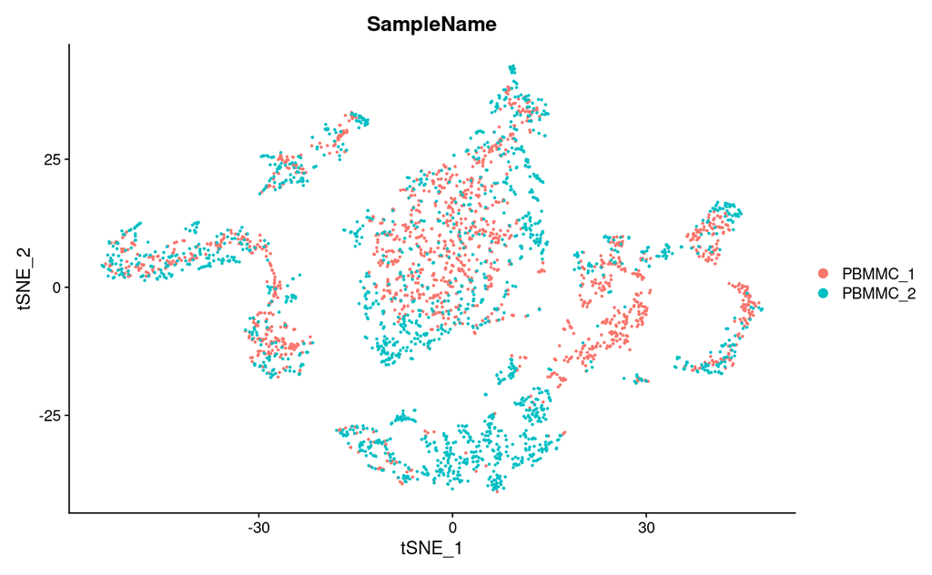

# 4

**Exercise**

1. Use `FindMarkers` to find differentially expressed marker genes between 2 other clusters of interest
2. Pick a gene at the top of this list and use the following visualisation tools to look at its expression pattern
- `VlnPlot`
- `RidgePlot`
- `FeaturePlot`

# 5

**Final Exercise!**

There are a number of different gene set libraries available in `enrichr` https://maayanlab.cloud/Enrichr/#libraries.

1. Have a look for over representation of functional terms in a different cluster of interest (for example Erythrocytes) and check against a different database